# Running miQC on Seurat objects

Compiled: July 19, 2021

This vigettte demonstrates the use of the miQC package in Seurat. Vignette is based off of the [miQC vignette](https://github.com/greenelab/miQC). If you use miQC in your work, please cite:

> *miQC: An adaptive probabilistic framework for quality control of single-cell RNA-sequencing data*

> Ariel A. Hippen, Matias M. Falco, Lukas M. Weber, Erdogan Pekcan Erkan, Kaiyang Zhang, Jennifer Anne Doherty, Anna Vähärautio, Casey S. Greene, Stephanie C. Hicks

> bioRxiv, 2021

> doi: [10.1101/2021.03.03.433798](https://www.biorxiv.org/content/10.1101/2021.03.03.433798v1)

> GitHub: https://github.com/greenelab/miQC

Prerequisites to install:

- [Seurat](https://satijalab.org/seurat/install)
- [SeuratData](https://github.com/satijalab/seurat-data)
- [flexmix](https://cran.r-project.org/web/packages/flexmix/index.html) which is wrapped by the miQC package.
  - *At this point, the miQC algorithm has been adapted for use in Seurat through installation of flexmix only*.

```r
library(Seurat)
library(SeuratData)
library(SeuratWrappers)
library(flexmix)
```

## Introduction

This vignette provides a basic example of how to run miQC, which allows users to perform cell-wise filtering of single-cell RNA-seq data for quality control. Single-cell RNA-seq data is very sensitive to tissue quality and choice of experimental workflow; it’s critical to ensure compromised cells and failed cell libraries are removed. A high proportion of reads mapping to mitochondrial DNA is one sign of a damaged cell, so most analyses will remove cells with mtRNA over a certain threshold, but those thresholds can be arbitrary and/or detrimentally stringent, especially for archived tumor tissues. miQC jointly models both the proportion of reads mapping to mtDNA genes and the number of detected genes with mixture models in a probabilistic framework to identify the low-quality cells in a given dataset.

## Example data

To demonstrate how to run miQC on a single-cell RNA-seq dataset, we’ll use the `pbmc3k`dataset from the SeuratData package.

```r
InstallData("pbmc3k")
data("pbmc3k")
pbmc3k
```

```
## An object of class Seurat
## 13714 features across 2700 samples within 1 assay
## Active assay: RNA (13714 features, 0 variable features)
```

## Seurat preprocessing

*miQC* requires two QC metrics for each single cell dataset: (1) the number of unique genes detected per cell and (2) the percent mitochondrial reads. The number of unique genes detected per cell are typically calculated and stored automatically as metadata (*nFeature_RNA*) upon creation of a Seurat object with `CreateSeuratObject`.

In order to calculate the percent mitochondrial reads in a cell we can use `PercentageFeatureSet`. Human mitochondrial genes start with *MT-* (and *mt-* for murine genes). For other IDs, we recommend using a *biomaRt* query to map to chromosomal location and identify all mitochondrial genes. We add this as metadata here to the Seurat object as `"percent.mt"`.

```r
pbmc3k[["percent.mt"]] <- PercentageFeatureSet(object = pbmc3k, pattern = "^MT-")
```

## miQC

We can visually inspect the `"percent.mt"` and `"nFeature_RNA"` values in the `pbmc3k` dataset.

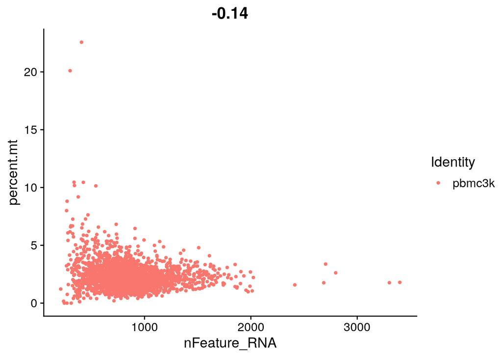

```r
FeatureScatter(pbmc3k, feature1 = "nFeature_RNA", feature2 = "percent.mt")
```

```r
pbmc3k <- RunMiQC(pbmc3k, percent.mt = "percent.mt", nFeature_RNA = "nFeature_RNA", posterior.cutoff = 0.75,
    model.slot = "flexmix_model")
```

This function is a wrapper for *flexmix*, which fits a mixture model on our data and returns the parameters of the two lines that best fit the data, as well as the posterior probability of each cell being derived from each distribution.

We can look at the parameters and posterior values directly with the functions

```r
flexmix::parameters(Misc(pbmc3k, "flexmix_model"))
```

```
##                         Comp.1       Comp.2
## coef.(Intercept)  2.004939e+00  7.141952783
## coef.nFeature_RNA 3.222184e-05 -0.004138082
## sigma             7.409008e-01  2.121678523
```

```r
head(flexmix::posterior(Misc(pbmc3k, "flexmix_model")))
```

```
##           [,1]       [,2]
## [1,] 0.9287557 0.07124429
## [2,] 0.7600390 0.23996098
## [3,] 0.9195142 0.08048576
## [4,] 0.9710883 0.02891168
## [5,] 0.9873697 0.01263027
## [6,] 0.9782177 0.02178231
```

Or we can visualize the model results using the *PlotMiQC* function, where `"miQC.probability"` represents the posterior probability of the cell belonging to the compromised condition:

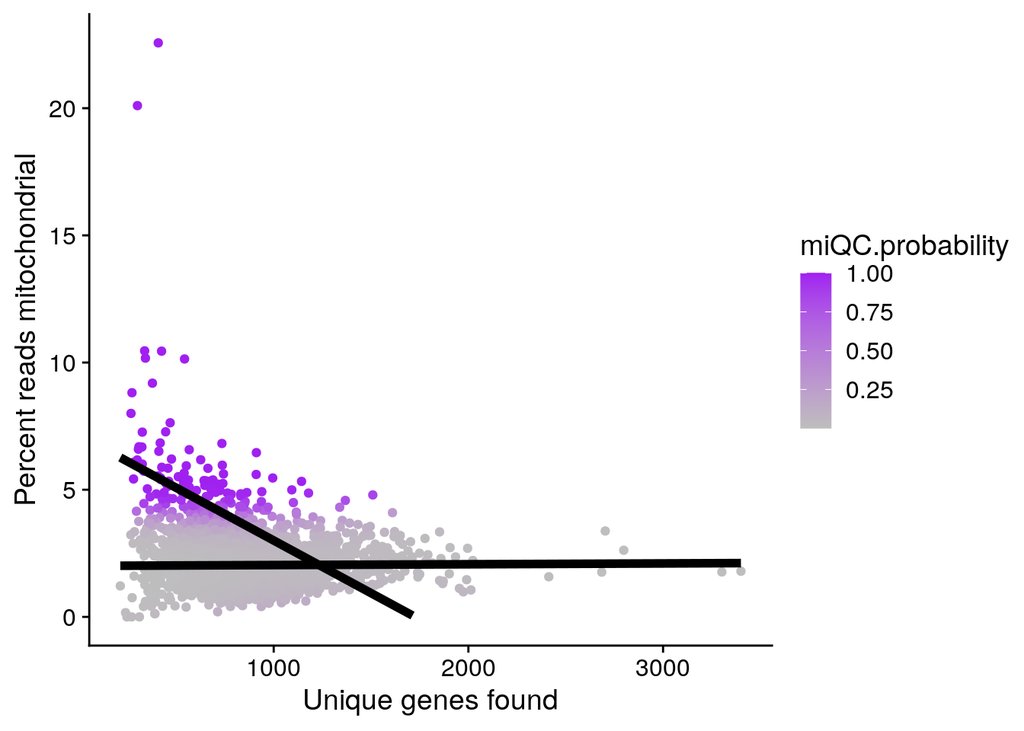

```r
PlotMiQC(pbmc3k, color.by = "miQC.probability") + ggplot2::scale_color_gradient(low = "grey", high = "purple")
```

As expected, the cells at the very top of the graph are almost certainly compromised, most likely to have been derived from the distribution with fewer unique genes and higher baseline mitochondrial expression.

We can use these posterior probabilities to choose which cells to keep, and visualize the consequences of this filtering with the *PlotMiQC* function. Recall when running `"RunMiQC"` we set the `"posterior.cutoff"` to be 0.75.

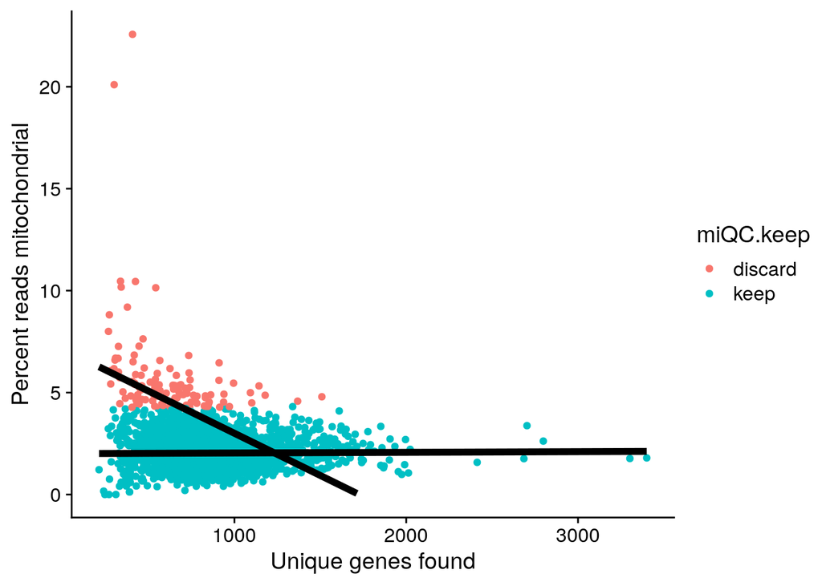

```r
PlotMiQC(pbmc3k, color.by = "miQC.keep")
```

To actually perform the filtering and remove the indicated cells from our Seurat object, we can subset the Seurat object parameter as such:

```r
pbmc3k_filtered <- subset(pbmc3k, miQC.keep == "keep")
pbmc3k_filtered
```

```
## An object of class Seurat
## 13714 features across 2593 samples within 1 assay
## Active assay: RNA (13714 features, 0 variable features)
```

## Extras

In most cases, a linear mixture model will be satisfactory as well as simplest, but *RunMiQC* also supports some non-linear mixture models: currently polynomials and b-splines. A user should only need to change the *model.type* parameter when making the model, and all visualization and filtering functions will work the same as with a linear model.

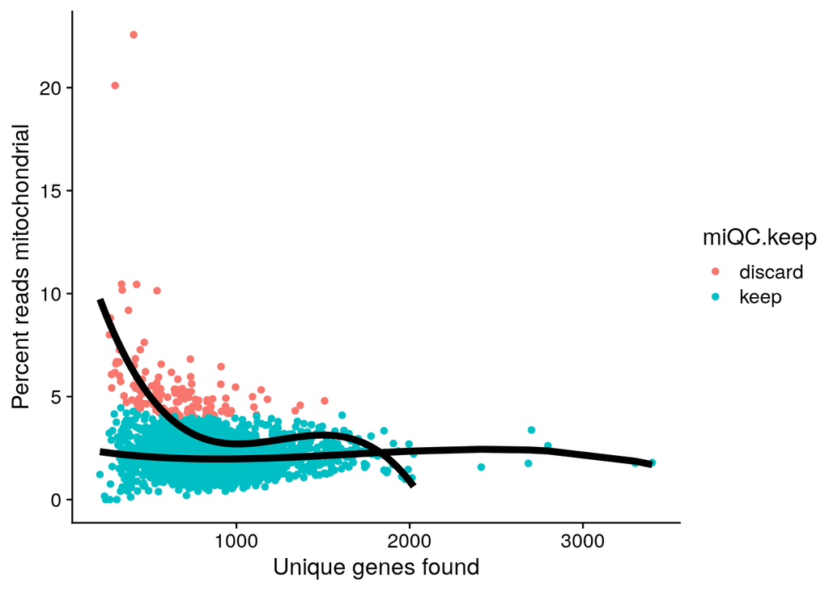

```r
pbmc3k <- RunMiQC(pbmc3k, percent.mt = "percent.mt", nFeature_RNA = "nFeature_RNA", posterior.cutoff = 0.75,
    model.slot = "flexmix_model", model.type = "spline")
PlotMiQC(pbmc3k, color.by = "miQC.keep")
```

Also, *RunMiQC* defaults to removing any cell with 75% or greater posterior probability of being compromised, but if we want to be more or less stringent, we can alter the *posterior.cutoff* parameter, like so:

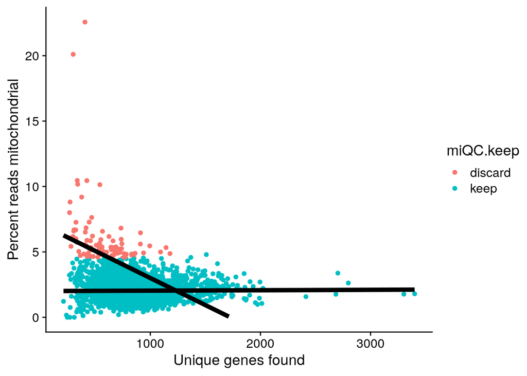

```r
pbmc3k <- RunMiQC(pbmc3k, percent.mt = "percent.mt", nFeature_RNA = "nFeature_RNA", posterior.cutoff = 0.9,
    model.slot = "flexmix_model")
PlotMiQC(pbmc3k, color.by = "miQC.keep")
```

Note that when performing miQC multiple times on different samples for the same experiment, it’s recommended to select the same *posterior_cutoff* for all, to give consistency in addition to the flexibility of sample-specific models.

## When not to use miQC

The miQC model is based on the assumption that there are a non-trivial number of compromised cells in the dataset, which is not true in all datasets. We recommend using *FeatureScatter* on a dataset before running miQC to see if the two-distribution model is appropriate. Look for the distinctive triangular shape where cells have a wide variety of mitochondrial percentages at lower gene counts and taper off to lower mitochondrial percentage at higher gene counts.

For example of a dataset where there’s not a significant number of compromised cells, so the two-distribution assumption is not met, we simulate an extreme case using the `"pbmc3k"` dataset here.

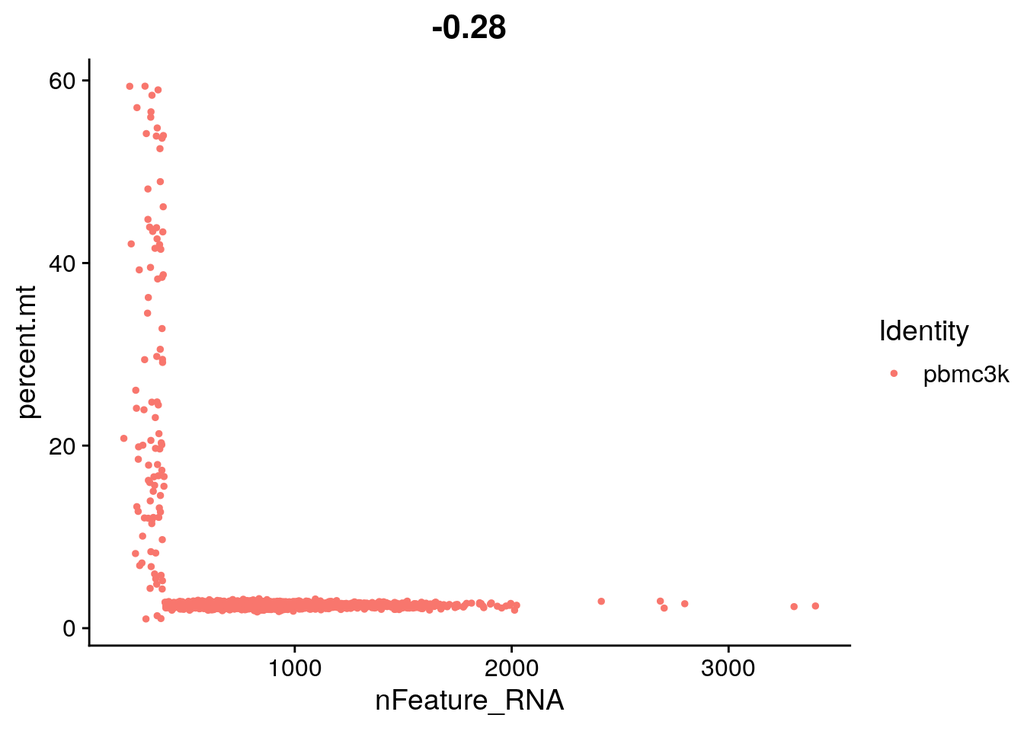

```r
set.seed(2021)
pbmc3k_extreme <- pbmc3k
simulated_percent_mt <- rnorm(mean = 2.5, sd = 0.2, n = ncol(pbmc3k_extreme))
pbmc3k_extreme$percent.mt <- ifelse(pbmc3k_extreme$nFeature_RNA > 400, simulated_percent_mt, pbmc3k_extreme$percent.mt)
simulated_percent_mt_2 <- runif(min = 0, max = 60, n = ncol(pbmc3k_extreme))
pbmc3k_extreme$percent.mt <- ifelse(pbmc3k_extreme$nFeature_RNA < 400, simulated_percent_mt_2, pbmc3k_extreme$percent.mt)
FeatureScatter(pbmc3k_extreme, feature1 = "nFeature_RNA", feature2 = "percent.mt")
```

The *RunMiQC* function will throw a warning if only one distribution is found. In these cases, we recommend using other filtering methods, such as a cutoff on mitochondrial percentage or percentile using the `"backup.option"` parameter to one of `"c("percentile", "percent", "pass", "halt")`.

```r
pbmc3k_extreme <- RunMiQC(pbmc3k_extreme, percent.mt = "percent.mt", nFeature_RNA = "nFeature_RNA",
    posterior.cutoff = 0.9, model.slot = "flexmix_model", backup.option = "percentile", backup.percentile = 0.95)
```

```
## Warning in RunMiQC(pbmc3k_extreme, percent.mt = "percent.mt", nFeature_RNA =
## "nFeature_RNA", : flexmix returned only 1 cluster
```

```
## defaulting to backup.percentile for filtering
```

```
## Warning: Adding a command log without an assay associated with it
```

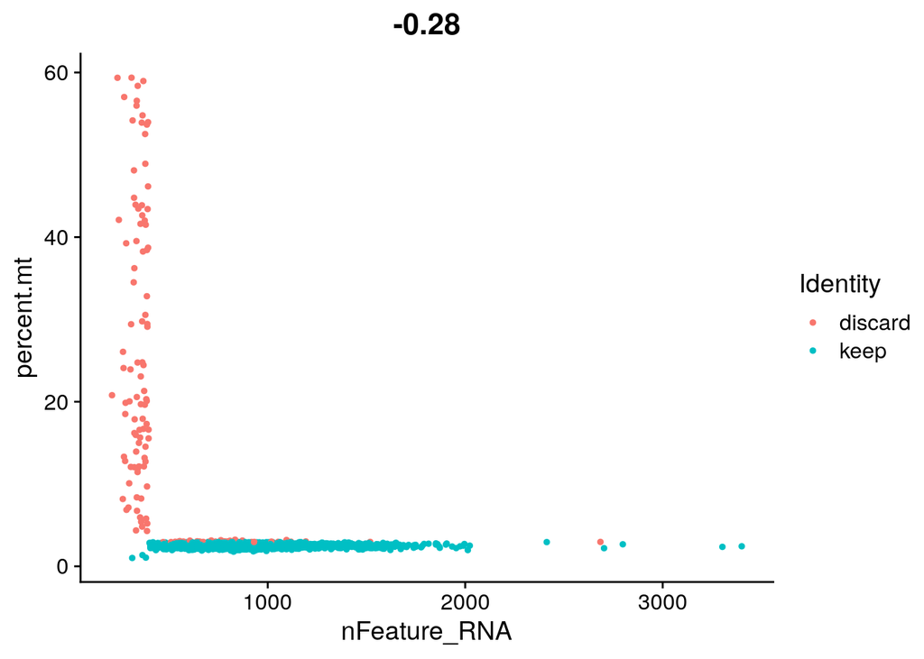

```r
FeatureScatter(pbmc3k_extreme, feature1 = "nFeature_RNA", feature2 = "percent.mt", group.by = "miQC.keep")
```